# Risk Factor Analysis

## Outcome Variable

**Outcome Variable:** y_rate_haz

## Predictor Variables

**Intervention Variable:** trth2o

**Adjustment Set:**

unadjusted

## Stratifying Variables

The analysis was stratified on these variable(s):

- agecat
- studyid
- country

## Data Summary

| agecat | studyid | country | trth2o | n_cell | n |
| --- | --- | --- | --- | --- | --- |
| 0-3 months | ki0047075b-MAL-ED | BANGLADESH | 1 | 132 | 134 |
| 0-3 months | ki0047075b-MAL-ED | BANGLADESH | 0 | 2 | 134 |
| 0-3 months | ki0047075b-MAL-ED | BRAZIL | 1 | 11 | 82 |
| 0-3 months | ki0047075b-MAL-ED | BRAZIL | 0 | 71 | 82 |
| 0-3 months | ki0047075b-MAL-ED | INDIA | 1 | 2 | 5 |
| 0-3 months | ki0047075b-MAL-ED | INDIA | 0 | 3 | 5 |
| 0-3 months | ki0047075b-MAL-ED | NEPAL | 1 | 45 | 55 |
| 0-3 months | ki0047075b-MAL-ED | NEPAL | 0 | 10 | 55 |
| 0-3 months | ki0047075b-MAL-ED | PERU | 1 | 36 | 45 |
| 0-3 months | ki0047075b-MAL-ED | PERU | 0 | 9 | 45 |
| 0-3 months | ki0047075b-MAL-ED | SOUTH AFRICA | 1 | 1 | 9 |
| 0-3 months | ki0047075b-MAL-ED | SOUTH AFRICA | 0 | 8 | 9 |
| 0-3 months | ki0047075b-MAL-ED | TANZANIA, UNITED REPUBLIC OF | 1 | 6 | 38 |
| 0-3 months | ki0047075b-MAL-ED | TANZANIA, UNITED REPUBLIC OF | 0 | 32 | 38 |
| 0-3 months | ki1000108-CMC-V-BCS-2002 | INDIA | 1 | 25 | 25 |
| 0-3 months | ki1000108-CMC-V-BCS-2002 | INDIA | 0 | 0 | 25 |
| 0-3 months | ki1000108-IRC | INDIA | 1 | 118 | 118 |
| 0-3 months | ki1000108-IRC | INDIA | 0 | 0 | 118 |
| 0-3 months | ki1017093b-PROVIDE | BANGLADESH | 1 | 14 | 640 |
| 0-3 months | ki1017093b-PROVIDE | BANGLADESH | 0 | 626 | 640 |
| 0-3 months | ki1017093c-NIH-Crypto | BANGLADESH | 1 | 402 | 721 |
| 0-3 months | ki1017093c-NIH-Crypto | BANGLADESH | 0 | 319 | 721 |
| 0-3 months | ki1113344-GMS-Nepal | NEPAL | 1 | 1 | 4 |
| 0-3 months | ki1113344-GMS-Nepal | NEPAL | 0 | 3 | 4 |
| 3-6 months | ki0047075b-MAL-ED | BANGLADESH | 1 | 130 | 132 |
| 3-6 months | ki0047075b-MAL-ED | BANGLADESH | 0 | 2 | 132 |
| 3-6 months | ki0047075b-MAL-ED | BRAZIL | 1 | 13 | 103 |
| 3-6 months | ki0047075b-MAL-ED | BRAZIL | 0 | 90 | 103 |
| 3-6 months | ki0047075b-MAL-ED | INDIA | 1 | 3 | 7 |
| 3-6 months | ki0047075b-MAL-ED | INDIA | 0 | 4 | 7 |

[output cut: 162 more lines]

The following strata were considered:

- agecat: 0-3 months, studyid: ki0047075b-MAL-ED, country: BANGLADESH
- agecat: 0-3 months, studyid: ki0047075b-MAL-ED, country: BRAZIL
- agecat: 0-3 months, studyid: ki0047075b-MAL-ED, country: INDIA
- agecat: 0-3 months, studyid: ki0047075b-MAL-ED, country: NEPAL
- agecat: 0-3 months, studyid: ki0047075b-MAL-ED, country: PERU
- agecat: 0-3 months, studyid: ki0047075b-MAL-ED, country: SOUTH AFRICA
- agecat: 0-3 months, studyid: ki0047075b-MAL-ED, country: TANZANIA, UNITED REPUBLIC OF
- agecat: 0-3 months, studyid: ki1000108-CMC-V-BCS-2002, country: INDIA
- agecat: 0-3 months, studyid: ki1000108-IRC, country: INDIA
- agecat: 0-3 months, studyid: ki1017093b-PROVIDE, country: BANGLADESH
- agecat: 0-3 months, studyid: ki1017093c-NIH-Crypto, country: BANGLADESH
- agecat: 0-3 months, studyid: ki1113344-GMS-Nepal, country: NEPAL
- agecat: 12-15 months, studyid: ki0047075b-MAL-ED, country: BANGLADESH
- agecat: 12-15 months, studyid: ki0047075b-MAL-ED, country: BRAZIL
- agecat: 12-15 months, studyid: ki0047075b-MAL-ED, country: INDIA
- agecat: 12-15 months, studyid: ki0047075b-MAL-ED, country: NEPAL
- agecat: 12-15 months, studyid: ki0047075b-MAL-ED, country: PERU
- agecat: 12-15 months, studyid: ki0047075b-MAL-ED, country: SOUTH AFRICA
- agecat: 12-15 months, studyid: ki0047075b-MAL-ED, country: TANZANIA, UNITED REPUBLIC OF
- agecat: 12-15 months, studyid: ki1000108-CMC-V-BCS-2002, country: INDIA
- agecat: 12-15 months, studyid: ki1000108-IRC, country: INDIA
- agecat: 12-15 months, studyid: ki1017093b-PROVIDE, country: BANGLADESH
- agecat: 12-15 months, studyid: ki1017093c-NIH-Crypto, country: BANGLADESH
- agecat: 12-15 months, studyid: ki1113344-GMS-Nepal, country: NEPAL
- agecat: 15-18 months, studyid: ki0047075b-MAL-ED, country: BANGLADESH
- agecat: 15-18 months, studyid: ki0047075b-MAL-ED, country: BRAZIL
- agecat: 15-18 months, studyid: ki0047075b-MAL-ED, country: INDIA
- agecat: 15-18 months, studyid: ki0047075b-MAL-ED, country: NEPAL
- agecat: 15-18 months, studyid: ki0047075b-MAL-ED, country: PERU
- agecat: 15-18 months, studyid: ki0047075b-MAL-ED, country: SOUTH AFRICA
- agecat: 15-18 months, studyid: ki0047075b-MAL-ED, country: TANZANIA, UNITED REPUBLIC OF
- agecat: 15-18 months, studyid: ki1000108-CMC-V-BCS-2002, country: INDIA
- agecat: 15-18 months, studyid: ki1000108-IRC, country: INDIA
- agecat: 15-18 months, studyid: ki1017093b-PROVIDE, country: BANGLADESH
- agecat: 15-18 months, studyid: ki1017093c-NIH-Crypto, country: BANGLADESH
- agecat: 15-18 months, studyid: ki1113344-GMS-Nepal, country: NEPAL
- agecat: 18-21 months, studyid: ki0047075b-MAL-ED, country: BANGLADESH
- agecat: 18-21 months, studyid: ki0047075b-MAL-ED, country: BRAZIL
- agecat: 18-21 months, studyid: ki0047075b-MAL-ED, country: INDIA
- agecat: 18-21 months, studyid: ki0047075b-MAL-ED, country: NEPAL
- agecat: 18-21 months, studyid: ki0047075b-MAL-ED, country: PERU
- agecat: 18-21 months, studyid: ki0047075b-MAL-ED, country: SOUTH AFRICA
- agecat: 18-21 months, studyid: ki0047075b-MAL-ED, country: TANZANIA, UNITED REPUBLIC OF
- agecat: 18-21 months, studyid: ki1000108-CMC-V-BCS-2002, country: INDIA
- agecat: 18-21 months, studyid: ki1000108-IRC, country: INDIA
- agecat: 18-21 months, studyid: ki1017093b-PROVIDE, country: BANGLADESH
- agecat: 18-21 months, studyid: ki1017093c-NIH-Crypto, country: BANGLADESH
- agecat: 18-21 months, studyid: ki1113344-GMS-Nepal, country: NEPAL
- agecat: 21-24 months, studyid: ki0047075b-MAL-ED, country: BANGLADESH
- agecat: 21-24 months, studyid: ki0047075b-MAL-ED, country: BRAZIL
- agecat: 21-24 months, studyid: ki0047075b-MAL-ED, country: INDIA
- agecat: 21-24 months, studyid: ki0047075b-MAL-ED, country: NEPAL
- agecat: 21-24 months, studyid: ki0047075b-MAL-ED, country: PERU
- agecat: 21-24 months, studyid: ki0047075b-MAL-ED, country: SOUTH AFRICA
- agecat: 21-24 months, studyid: ki0047075b-MAL-ED, country: TANZANIA, UNITED REPUBLIC OF
- agecat: 21-24 months, studyid: ki1000108-CMC-V-BCS-2002, country: INDIA
- agecat: 21-24 months, studyid: ki1000108-IRC, country: INDIA
- agecat: 21-24 months, studyid: ki1017093b-PROVIDE, country: BANGLADESH
- agecat: 21-24 months, studyid: ki1017093c-NIH-Crypto, country: BANGLADESH
- agecat: 21-24 months, studyid: ki1113344-GMS-Nepal, country: NEPAL
- agecat: 3-6 months, studyid: ki0047075b-MAL-ED, country: BANGLADESH
- agecat: 3-6 months, studyid: ki0047075b-MAL-ED, country: BRAZIL
- agecat: 3-6 months, studyid: ki0047075b-MAL-ED, country: INDIA
- agecat: 3-6 months, studyid: ki0047075b-MAL-ED, country: NEPAL
- agecat: 3-6 months, studyid: ki0047075b-MAL-ED, country: PERU
- agecat: 3-6 months, studyid: ki0047075b-MAL-ED, country: SOUTH AFRICA
- agecat: 3-6 months, studyid: ki0047075b-MAL-ED, country: TANZANIA, UNITED REPUBLIC OF
- agecat: 3-6 months, studyid: ki1000108-CMC-V-BCS-2002, country: INDIA
- agecat: 3-6 months, studyid: ki1000108-IRC, country: INDIA
- agecat: 3-6 months, studyid: ki1017093b-PROVIDE, country: BANGLADESH
- agecat: 3-6 months, studyid: ki1017093c-NIH-Crypto, country: BANGLADESH
- agecat: 3-6 months, studyid: ki1113344-GMS-Nepal, country: NEPAL
- agecat: 6-9 months, studyid: ki0047075b-MAL-ED, country: BANGLADESH
- agecat: 6-9 months, studyid: ki0047075b-MAL-ED, country: BRAZIL
- agecat: 6-9 months, studyid: ki0047075b-MAL-ED, country: INDIA
- agecat: 6-9 months, studyid: ki0047075b-MAL-ED, country: NEPAL
- agecat: 6-9 months, studyid: ki0047075b-MAL-ED, country: PERU
- agecat: 6-9 months, studyid: ki0047075b-MAL-ED, country: SOUTH AFRICA
- agecat: 6-9 months, studyid: ki0047075b-MAL-ED, country: TANZANIA, UNITED REPUBLIC OF
- agecat: 6-9 months, studyid: ki1000108-CMC-V-BCS-2002, country: INDIA
- agecat: 6-9 months, studyid: ki1000108-IRC, country: INDIA
- agecat: 6-9 months, studyid: ki1017093b-PROVIDE, country: BANGLADESH
- agecat: 6-9 months, studyid: ki1017093c-NIH-Crypto, country: BANGLADESH
- agecat: 6-9 months, studyid: ki1113344-GMS-Nepal, country: NEPAL
- agecat: 9-12 months, studyid: ki0047075b-MAL-ED, country: BANGLADESH
- agecat: 9-12 months, studyid: ki0047075b-MAL-ED, country: BRAZIL
- agecat: 9-12 months, studyid: ki0047075b-MAL-ED, country: INDIA
- agecat: 9-12 months, studyid: ki0047075b-MAL-ED, country: NEPAL
- agecat: 9-12 months, studyid: ki0047075b-MAL-ED, country: PERU
- agecat: 9-12 months, studyid: ki0047075b-MAL-ED, country: SOUTH AFRICA
- agecat: 9-12 months, studyid: ki0047075b-MAL-ED, country: TANZANIA, UNITED REPUBLIC OF
- agecat: 9-12 months, studyid: ki1000108-CMC-V-BCS-2002, country: INDIA
- agecat: 9-12 months, studyid: ki1000108-IRC, country: INDIA
- agecat: 9-12 months, studyid: ki1017093b-PROVIDE, country: BANGLADESH
- agecat: 9-12 months, studyid: ki1017093c-NIH-Crypto, country: BANGLADESH
- agecat: 9-12 months, studyid: ki1113344-GMS-Nepal, country: NEPAL

### Dropped Strata

Some strata were dropped due to rare outcomes:

- agecat: 0-3 months, studyid: ki0047075b-MAL-ED, country: BANGLADESH
- agecat: 0-3 months, studyid: ki0047075b-MAL-ED, country: INDIA
- agecat: 0-3 months, studyid: ki0047075b-MAL-ED, country: SOUTH AFRICA
- agecat: 0-3 months, studyid: ki1000108-CMC-V-BCS-2002, country: INDIA
- agecat: 0-3 months, studyid: ki1000108-IRC, country: INDIA
- agecat: 0-3 months, studyid: ki1113344-GMS-Nepal, country: NEPAL
- agecat: 3-6 months, studyid: ki0047075b-MAL-ED, country: BANGLADESH
- agecat: 3-6 months, studyid: ki0047075b-MAL-ED, country: INDIA
- agecat: 3-6 months, studyid: ki0047075b-MAL-ED, country: SOUTH AFRICA
- agecat: 3-6 months, studyid: ki1000108-CMC-V-BCS-2002, country: INDIA
- agecat: 3-6 months, studyid: ki1000108-IRC, country: INDIA
- agecat: 3-6 months, studyid: ki1113344-GMS-Nepal, country: NEPAL
- agecat: 6-9 months, studyid: ki0047075b-MAL-ED, country: BANGLADESH
- agecat: 6-9 months, studyid: ki0047075b-MAL-ED, country: INDIA
- agecat: 6-9 months, studyid: ki0047075b-MAL-ED, country: SOUTH AFRICA
- agecat: 6-9 months, studyid: ki1000108-CMC-V-BCS-2002, country: INDIA
- agecat: 6-9 months, studyid: ki1000108-IRC, country: INDIA
- agecat: 6-9 months, studyid: ki1113344-GMS-Nepal, country: NEPAL
- agecat: 9-12 months, studyid: ki0047075b-MAL-ED, country: BANGLADESH
- agecat: 9-12 months, studyid: ki0047075b-MAL-ED, country: INDIA
- agecat: 9-12 months, studyid: ki0047075b-MAL-ED, country: SOUTH AFRICA
- agecat: 9-12 months, studyid: ki1000108-CMC-V-BCS-2002, country: INDIA
- agecat: 9-12 months, studyid: ki1000108-IRC, country: INDIA
- agecat: 9-12 months, studyid: ki1113344-GMS-Nepal, country: NEPAL
- agecat: 12-15 months, studyid: ki0047075b-MAL-ED, country: BANGLADESH
- agecat: 12-15 months, studyid: ki0047075b-MAL-ED, country: INDIA
- agecat: 12-15 months, studyid: ki0047075b-MAL-ED, country: SOUTH AFRICA
- agecat: 12-15 months, studyid: ki1000108-CMC-V-BCS-2002, country: INDIA
- agecat: 12-15 months, studyid: ki1000108-IRC, country: INDIA
- agecat: 12-15 months, studyid: ki1113344-GMS-Nepal, country: NEPAL
- agecat: 15-18 months, studyid: ki0047075b-MAL-ED, country: BANGLADESH
- agecat: 15-18 months, studyid: ki0047075b-MAL-ED, country: INDIA
- agecat: 15-18 months, studyid: ki0047075b-MAL-ED, country: SOUTH AFRICA
- agecat: 15-18 months, studyid: ki1000108-CMC-V-BCS-2002, country: INDIA
- agecat: 15-18 months, studyid: ki1000108-IRC, country: INDIA
- agecat: 15-18 months, studyid: ki1113344-GMS-Nepal, country: NEPAL
- agecat: 18-21 months, studyid: ki0047075b-MAL-ED, country: BANGLADESH
- agecat: 18-21 months, studyid: ki0047075b-MAL-ED, country: INDIA
- agecat: 18-21 months, studyid: ki0047075b-MAL-ED, country: SOUTH AFRICA
- agecat: 18-21 months, studyid: ki1000108-CMC-V-BCS-2002, country: INDIA
- agecat: 18-21 months, studyid: ki1000108-IRC, country: INDIA
- agecat: 18-21 months, studyid: ki1113344-GMS-Nepal, country: NEPAL
- agecat: 21-24 months, studyid: ki0047075b-MAL-ED, country: BANGLADESH
- agecat: 21-24 months, studyid: ki0047075b-MAL-ED, country: INDIA
- agecat: 21-24 months, studyid: ki0047075b-MAL-ED, country: SOUTH AFRICA
- agecat: 21-24 months, studyid: ki1000108-CMC-V-BCS-2002, country: INDIA
- agecat: 21-24 months, studyid: ki1000108-IRC, country: INDIA
- agecat: 21-24 months, studyid: ki1113344-GMS-Nepal, country: NEPAL

## Methods Detail

We’re interested in the causal parameters $E[Y_a]$ for all values of $a \in \mathcal{A}$. These parameters represent the mean outcome if, possibly contrary to fact, we intervened to set all units to have $A=a$. Under the randomization and positivity assumptions, these are identified by the statistical parameters $\psi_a=E_W[E_{Y|A,W}(Y|A=a,W)]$. In addition, we’re interested in the mean of $Y$, $E[Y]$ under no intervention (the observed mean). We will estimate these parameters by using SuperLearner to fit the relevant likelihood factors – $E_{Y|A,W}(Y|A=a,W)$ and $p(A=a|W)$, and then updating our likelihood fit using a joint TMLE.

For unadjusted analyses ($W=\{\}$), initial likelihoods were estimated using Lrnr_glm to estimate the simple $E(Y|A)$ and Lrnr_mean to estimate $p(A)$. For adjusted analyses, a small library containing Lrnr_glmnet, Lrnr_xgboost, and Lrnr_mean was used.

Having estimated these parameters, we will then use the delta method to estimate relative risks and attributable risks relative to a prespecified baseline level of $A$.

# Results Detail

## Results Plots

[figure not shown]

[figure not shown]

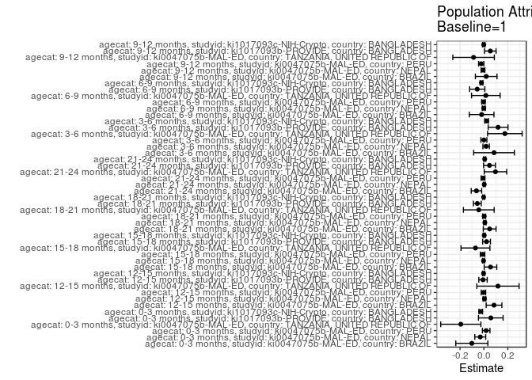

## Results Table

### Parameter: TSM

| agecat | studyid | country | intervention_level | baseline_level | estimate | ci_lower | ci_upper |
| --- | --- | --- | --- | --- | --- | --- | --- |
| 0-3 months | ki0047075b-MAL-ED | BRAZIL | 1 | NA | 0.2703280 | 0.1406068 | 0.4000492 |
| 0-3 months | ki0047075b-MAL-ED | BRAZIL | 0 | NA | 0.1534405 | 0.0688958 | 0.2379851 |
| 0-3 months | ki0047075b-MAL-ED | NEPAL | 1 | NA | 0.0299729 | -0.0483735 | 0.1083192 |
| 0-3 months | ki0047075b-MAL-ED | NEPAL | 0 | NA | -0.1377199 | -0.3574089 | 0.0819692 |
| 0-3 months | ki0047075b-MAL-ED | PERU | 1 | NA | -0.2775269 | -0.3807449 | -0.1743088 |
| 0-3 months | ki0047075b-MAL-ED | PERU | 0 | NA | -0.1825068 | -0.2881511 | -0.0768626 |
| 0-3 months | ki0047075b-MAL-ED | TANZANIA, UNITED REPUBLIC OF | 1 | NA | -0.0521782 | -0.2154773 | 0.1111208 |
| 0-3 months | ki0047075b-MAL-ED | TANZANIA, UNITED REPUBLIC OF | 0 | NA | -0.2818987 | -0.3925793 | -0.1712181 |
| 0-3 months | ki1017093b-PROVIDE | BANGLADESH | 1 | NA | -0.2456990 | -0.3499994 | -0.1413986 |
| 0-3 months | ki1017093b-PROVIDE | BANGLADESH | 0 | NA | -0.1867507 | -0.2043522 | -0.1691492 |
| 0-3 months | ki1017093c-NIH-Crypto | BANGLADESH | 1 | NA | -0.2045525 | -0.2293944 | -0.1797106 |
| 0-3 months | ki1017093c-NIH-Crypto | BANGLADESH | 0 | NA | -0.2649182 | -0.2882487 | -0.2415877 |
| 3-6 months | ki0047075b-MAL-ED | BRAZIL | 1 | NA | 0.0084511 | -0.1798343 | 0.1967364 |
| 3-6 months | ki0047075b-MAL-ED | BRAZIL | 0 | NA | 0.1055408 | 0.0555535 | 0.1555281 |
| 3-6 months | ki0047075b-MAL-ED | NEPAL | 1 | NA | -0.0272718 | -0.0789435 | 0.0243998 |
| 3-6 months | ki0047075b-MAL-ED | NEPAL | 0 | NA | 0.0816088 | -0.0571807 | 0.2203982 |
| 3-6 months | ki0047075b-MAL-ED | PERU | 1 | NA | 0.0185808 | -0.0628798 | 0.1000414 |
| 3-6 months | ki0047075b-MAL-ED | PERU | 0 | NA | 0.0181999 | -0.0741782 | 0.1105781 |
| 3-6 months | ki0047075b-MAL-ED | TANZANIA, UNITED REPUBLIC OF | 1 | NA | -0.2457527 | -0.3985192 | -0.0929862 |
| 3-6 months | ki0047075b-MAL-ED | TANZANIA, UNITED REPUBLIC OF | 0 | NA | -0.0410643 | -0.1081175 | 0.0259890 |
| 3-6 months | ki1017093b-PROVIDE | BANGLADESH | 1 | NA | -0.1456721 | -0.2292668 | -0.0620773 |
| 3-6 months | ki1017093b-PROVIDE | BANGLADESH | 0 | NA | -0.0241167 | -0.0402124 | -0.0080211 |
| 3-6 months | ki1017093c-NIH-Crypto | BANGLADESH | 1 | NA | 0.0039791 | -0.0180169 | 0.0259752 |
| 3-6 months | ki1017093c-NIH-Crypto | BANGLADESH | 0 | NA | 0.0545940 | 0.0289837 | 0.0802043 |
| 6-9 months | ki0047075b-MAL-ED | BRAZIL | 1 | NA | 0.0522410 | -0.0496252 | 0.1541071 |
| 6-9 months | ki0047075b-MAL-ED | BRAZIL | 0 | NA | 0.0303046 | -0.0298461 | 0.0904554 |
| 6-9 months | ki0047075b-MAL-ED | NEPAL | 1 | NA | -0.0526312 | -0.0877364 | -0.0175259 |
| 6-9 months | ki0047075b-MAL-ED | NEPAL | 0 | NA | -0.0590052 | -0.1238753 | 0.0058650 |
| 6-9 months | ki0047075b-MAL-ED | PERU | 1 | NA | -0.0833413 | -0.1434503 | -0.0232322 |
| 6-9 months | ki0047075b-MAL-ED | PERU | 0 | NA | -0.1023565 | -0.1409183 | -0.0637946 |

[output cut: 66 more lines]

### Parameter: E(Y)

| agecat | studyid | country | intervention_level | baseline_level | estimate | ci_lower | ci_upper |
| --- | --- | --- | --- | --- | --- | --- | --- |
| 0-3 months | ki0047075b-MAL-ED | BRAZIL | NA | NA | 0.1691205 | 0.0933788 | 0.2448622 |
| 0-3 months | ki0047075b-MAL-ED | NEPAL | NA | NA | -0.0005167 | -0.0779898 | 0.0769564 |
| 0-3 months | ki0047075b-MAL-ED | PERU | NA | NA | -0.2585229 | -0.3444943 | -0.1725514 |
| 0-3 months | ki0047075b-MAL-ED | TANZANIA, UNITED REPUBLIC OF | NA | NA | -0.2456271 | -0.3460284 | -0.1452257 |
| 0-3 months | ki1017093b-PROVIDE | BANGLADESH | NA | NA | -0.1880402 | -0.2054115 | -0.1706689 |
| 0-3 months | ki1017093c-NIH-Crypto | BANGLADESH | NA | NA | -0.2312607 | -0.2486732 | -0.2138483 |
| 3-6 months | ki0047075b-MAL-ED | BRAZIL | NA | NA | 0.0932868 | 0.0431702 | 0.1434034 |
| 3-6 months | ki0047075b-MAL-ED | NEPAL | NA | NA | -0.0086825 | -0.0584538 | 0.0410888 |
| 3-6 months | ki0047075b-MAL-ED | PERU | NA | NA | 0.0185031 | -0.0490183 | 0.0860244 |
| 3-6 months | ki0047075b-MAL-ED | TANZANIA, UNITED REPUBLIC OF | NA | NA | -0.0703055 | -0.1355760 | -0.0050350 |
| 3-6 months | ki1017093b-PROVIDE | BANGLADESH | NA | NA | -0.0269625 | -0.0428628 | -0.0110622 |
| 3-6 months | ki1017093c-NIH-Crypto | BANGLADESH | NA | NA | 0.0267740 | 0.0099602 | 0.0435879 |
| 6-9 months | ki0047075b-MAL-ED | BRAZIL | NA | NA | 0.0330733 | -0.0210538 | 0.0872004 |
| 6-9 months | ki0047075b-MAL-ED | NEPAL | NA | NA | -0.0537194 | -0.0848710 | -0.0225678 |
| 6-9 months | ki0047075b-MAL-ED | PERU | NA | NA | -0.0872219 | -0.1357552 | -0.0386886 |
| 6-9 months | ki0047075b-MAL-ED | TANZANIA, UNITED REPUBLIC OF | NA | NA | -0.0615499 | -0.1727971 | 0.0496973 |
| 6-9 months | ki1017093b-PROVIDE | BANGLADESH | NA | NA | -0.0614264 | -0.0722690 | -0.0505838 |
| 6-9 months | ki1017093c-NIH-Crypto | BANGLADESH | NA | NA | -0.0313638 | -0.0441155 | -0.0186120 |
| 9-12 months | ki0047075b-MAL-ED | BRAZIL | NA | NA | 0.0012215 | -0.0398479 | 0.0422909 |
| 9-12 months | ki0047075b-MAL-ED | NEPAL | NA | NA | -0.0679160 | -0.0976463 | -0.0381856 |
| 9-12 months | ki0047075b-MAL-ED | PERU | NA | NA | -0.0252263 | -0.0764321 | 0.0259796 |
| 9-12 months | ki0047075b-MAL-ED | TANZANIA, UNITED REPUBLIC OF | NA | NA | -0.1507799 | -0.2608943 | -0.0406655 |
| 9-12 months | ki1017093b-PROVIDE | BANGLADESH | NA | NA | -0.0630470 | -0.0740183 | -0.0520757 |
| 9-12 months | ki1017093c-NIH-Crypto | BANGLADESH | NA | NA | -0.0342995 | -0.0452397 | -0.0233593 |
| 12-15 months | ki0047075b-MAL-ED | BRAZIL | NA | NA | 0.0081475 | -0.0199315 | 0.0362265 |
| 12-15 months | ki0047075b-MAL-ED | NEPAL | NA | NA | -0.0274684 | -0.0511861 | -0.0037507 |
| 12-15 months | ki0047075b-MAL-ED | PERU | NA | NA | -0.0674136 | -0.1121894 | -0.0226379 |
| 12-15 months | ki0047075b-MAL-ED | TANZANIA, UNITED REPUBLIC OF | NA | NA | -0.0898961 | -0.1469951 | -0.0327972 |
| 12-15 months | ki1017093b-PROVIDE | BANGLADESH | NA | NA | -0.0409107 | -0.0510053 | -0.0308161 |
| 12-15 months | ki1017093c-NIH-Crypto | BANGLADESH | NA | NA | -0.0383313 | -0.0478154 | -0.0288473 |
| 15-18 months | ki0047075b-MAL-ED | BRAZIL | NA | NA | -0.0199999 | -0.0494604 | 0.0094605 |
| 15-18 months | ki0047075b-MAL-ED | NEPAL | NA | NA | -0.0444437 | -0.0669103 | -0.0219771 |
| 15-18 months | ki0047075b-MAL-ED | PERU | NA | NA | -0.0369648 | -0.0765062 | 0.0025766 |
| 15-18 months | ki0047075b-MAL-ED | TANZANIA, UNITED REPUBLIC OF | NA | NA | -0.0532002 | -0.1040727 | -0.0023277 |
| 15-18 months | ki1017093b-PROVIDE | BANGLADESH | NA | NA | -0.0376437 | -0.0463882 | -0.0288992 |
| 15-18 months | ki1017093c-NIH-Crypto | BANGLADESH | NA | NA | -0.0169074 | -0.0252557 | -0.0085590 |
| 18-21 months | ki0047075b-MAL-ED | BRAZIL | NA | NA | -0.0238213 | -0.0596356 | 0.0119930 |
| 18-21 months | ki0047075b-MAL-ED | NEPAL | NA | NA | -0.0451263 | -0.0665050 | -0.0237475 |
| 18-21 months | ki0047075b-MAL-ED | PERU | NA | NA | -0.0027968 | -0.0327190 | 0.0271255 |
| 18-21 months | ki0047075b-MAL-ED | TANZANIA, UNITED REPUBLIC OF | NA | NA | -0.0708505 | -0.1214725 | -0.0202285 |
| 18-21 months | ki1017093b-PROVIDE | BANGLADESH | NA | NA | -0.0109399 | -0.0190984 | -0.0027814 |
| 18-21 months | ki1017093c-NIH-Crypto | BANGLADESH | NA | NA | -0.0279687 | -0.0360019 | -0.0199355 |
| 21-24 months | ki0047075b-MAL-ED | BRAZIL | NA | NA | 0.0081826 | -0.0112535 | 0.0276187 |
| 21-24 months | ki0047075b-MAL-ED | NEPAL | NA | NA | 0.0062925 | -0.0130572 | 0.0256421 |
| 21-24 months | ki0047075b-MAL-ED | PERU | NA | NA | 0.0699008 | 0.0386257 | 0.1011760 |
| 21-24 months | ki0047075b-MAL-ED | TANZANIA, UNITED REPUBLIC OF | NA | NA | -0.0026757 | -0.0477263 | 0.0423749 |
| 21-24 months | ki1017093b-PROVIDE | BANGLADESH | NA | NA | 0.0462342 | 0.0375872 | 0.0548812 |
| 21-24 months | ki1017093c-NIH-Crypto | BANGLADESH | NA | NA | 0.0587621 | 0.0505315 | 0.0669927 |

### Parameter: ATE

| agecat | studyid | country | intervention_level | baseline_level | estimate | ci_lower | ci_upper |
| --- | --- | --- | --- | --- | --- | --- | --- |
| 0-3 months | ki0047075b-MAL-ED | BRAZIL | 1 | 1 | 0.0000000 | 0.0000000 | 0.0000000 |
| 0-3 months | ki0047075b-MAL-ED | BRAZIL | 0 | 1 | -0.1168875 | -0.2717274 | 0.0379524 |
| 0-3 months | ki0047075b-MAL-ED | NEPAL | 1 | 1 | 0.0000000 | 0.0000000 | 0.0000000 |
| 0-3 months | ki0047075b-MAL-ED | NEPAL | 0 | 1 | -0.1676927 | -0.4009339 | 0.0655484 |
| 0-3 months | ki0047075b-MAL-ED | PERU | 1 | 1 | 0.0000000 | 0.0000000 | 0.0000000 |
| 0-3 months | ki0047075b-MAL-ED | PERU | 0 | 1 | 0.0950200 | -0.0526779 | 0.2427179 |
| 0-3 months | ki0047075b-MAL-ED | TANZANIA, UNITED REPUBLIC OF | 1 | 1 | 0.0000000 | 0.0000000 | 0.0000000 |
| 0-3 months | ki0047075b-MAL-ED | TANZANIA, UNITED REPUBLIC OF | 0 | 1 | -0.2297205 | -0.4269939 | -0.0324471 |
| 0-3 months | ki1017093b-PROVIDE | BANGLADESH | 1 | 1 | 0.0000000 | 0.0000000 | 0.0000000 |
| 0-3 months | ki1017093b-PROVIDE | BANGLADESH | 0 | 1 | 0.0589483 | -0.0468269 | 0.1647235 |
| 0-3 months | ki1017093c-NIH-Crypto | BANGLADESH | 1 | 1 | 0.0000000 | 0.0000000 | 0.0000000 |
| 0-3 months | ki1017093c-NIH-Crypto | BANGLADESH | 0 | 1 | -0.0603657 | -0.0944454 | -0.0262859 |
| 3-6 months | ki0047075b-MAL-ED | BRAZIL | 1 | 1 | 0.0000000 | 0.0000000 | 0.0000000 |
| 3-6 months | ki0047075b-MAL-ED | BRAZIL | 0 | 1 | 0.0970898 | -0.0977181 | 0.2918977 |
| 3-6 months | ki0047075b-MAL-ED | NEPAL | 1 | 1 | 0.0000000 | 0.0000000 | 0.0000000 |
| 3-6 months | ki0047075b-MAL-ED | NEPAL | 0 | 1 | 0.1088806 | -0.0392155 | 0.2569768 |
| 3-6 months | ki0047075b-MAL-ED | PERU | 1 | 1 | 0.0000000 | 0.0000000 | 0.0000000 |
| 3-6 months | ki0047075b-MAL-ED | PERU | 0 | 1 | -0.0003809 | -0.1235456 | 0.1227839 |
| 3-6 months | ki0047075b-MAL-ED | TANZANIA, UNITED REPUBLIC OF | 1 | 1 | 0.0000000 | 0.0000000 | 0.0000000 |
| 3-6 months | ki0047075b-MAL-ED | TANZANIA, UNITED REPUBLIC OF | 0 | 1 | 0.2046884 | 0.0378539 | 0.3715229 |
| 3-6 months | ki1017093b-PROVIDE | BANGLADESH | 1 | 1 | 0.0000000 | 0.0000000 | 0.0000000 |
| 3-6 months | ki1017093b-PROVIDE | BANGLADESH | 0 | 1 | 0.1215554 | 0.0364251 | 0.2066856 |
| 3-6 months | ki1017093c-NIH-Crypto | BANGLADESH | 1 | 1 | 0.0000000 | 0.0000000 | 0.0000000 |
| 3-6 months | ki1017093c-NIH-Crypto | BANGLADESH | 0 | 1 | 0.0506149 | 0.0168552 | 0.0843745 |
| 6-9 months | ki0047075b-MAL-ED | BRAZIL | 1 | 1 | 0.0000000 | 0.0000000 | 0.0000000 |
| 6-9 months | ki0047075b-MAL-ED | BRAZIL | 0 | 1 | -0.0219363 | -0.1402360 | 0.0963634 |
| 6-9 months | ki0047075b-MAL-ED | NEPAL | 1 | 1 | 0.0000000 | 0.0000000 | 0.0000000 |
| 6-9 months | ki0047075b-MAL-ED | NEPAL | 0 | 1 | -0.0063740 | -0.0801338 | 0.0673858 |
| 6-9 months | ki0047075b-MAL-ED | PERU | 1 | 1 | 0.0000000 | 0.0000000 | 0.0000000 |
| 6-9 months | ki0047075b-MAL-ED | PERU | 0 | 1 | -0.0190152 | -0.0904303 | 0.0523999 |

[output cut: 66 more lines]

### Parameter: PAR

| agecat | studyid | country | intervention_level | baseline_level | estimate | ci_lower | ci_upper |
| --- | --- | --- | --- | --- | --- | --- | --- |
| 0-3 months | ki0047075b-MAL-ED | BRAZIL | 1 | NA | -0.1012075 | -0.2355565 | 0.0331416 |
| 0-3 months | ki0047075b-MAL-ED | NEPAL | 1 | NA | -0.0304896 | -0.0762715 | 0.0152923 |
| 0-3 months | ki0047075b-MAL-ED | PERU | 1 | NA | 0.0190040 | -0.0125984 | 0.0506064 |
| 0-3 months | ki0047075b-MAL-ED | TANZANIA, UNITED REPUBLIC OF | 1 | NA | -0.1934488 | -0.3617521 | -0.0251456 |
| 0-3 months | ki1017093b-PROVIDE | BANGLADESH | 1 | NA | 0.0576588 | -0.0454742 | 0.1607918 |
| 0-3 months | ki1017093c-NIH-Crypto | BANGLADESH | 1 | NA | -0.0267082 | -0.0419447 | -0.0114717 |
| 3-6 months | ki0047075b-MAL-ED | BRAZIL | 1 | NA | 0.0848357 | -0.0854997 | 0.2551712 |
| 3-6 months | ki0047075b-MAL-ED | NEPAL | 1 | NA | 0.0185894 | -0.0082233 | 0.0454020 |
| 3-6 months | ki0047075b-MAL-ED | PERU | 1 | NA | -0.0000777 | -0.0252134 | 0.0250580 |
| 3-6 months | ki0047075b-MAL-ED | TANZANIA, UNITED REPUBLIC OF | 1 | NA | 0.1754472 | 0.0307753 | 0.3201191 |
| 3-6 months | ki1017093b-PROVIDE | BANGLADESH | 1 | NA | 0.1187096 | 0.0356945 | 0.2017246 |
| 3-6 months | ki1017093c-NIH-Crypto | BANGLADESH | 1 | NA | 0.0227949 | 0.0074759 | 0.0381139 |
| 6-9 months | ki0047075b-MAL-ED | BRAZIL | 1 | NA | -0.0191677 | -0.1225460 | 0.0842107 |
| 6-9 months | ki0047075b-MAL-ED | NEPAL | 1 | NA | -0.0010882 | -0.0136922 | 0.0115157 |
| 6-9 months | ki0047075b-MAL-ED | PERU | 1 | NA | -0.0038807 | -0.0186155 | 0.0108542 |
| 6-9 months | ki0047075b-MAL-ED | TANZANIA, UNITED REPUBLIC OF | 1 | NA | 0.0160858 | -0.1035361 | 0.1357077 |
| 6-9 months | ki1017093b-PROVIDE | BANGLADESH | 1 | NA | -0.0558890 | -0.1197582 | 0.0079801 |
| 6-9 months | ki1017093c-NIH-Crypto | BANGLADESH | 1 | NA | -0.0204021 | -0.0319659 | -0.0088382 |
| 9-12 months | ki0047075b-MAL-ED | BRAZIL | 1 | NA | 0.0191421 | -0.0715286 | 0.1098129 |
| 9-12 months | ki0047075b-MAL-ED | NEPAL | 1 | NA | -0.0076908 | -0.0234363 | 0.0080547 |
| 9-12 months | ki0047075b-MAL-ED | PERU | 1 | NA | -0.0226924 | -0.0445240 | -0.0008608 |
| 9-12 months | ki0047075b-MAL-ED | TANZANIA, UNITED REPUBLIC OF | 1 | NA | -0.0864725 | -0.2603056 | 0.0873606 |
| 9-12 months | ki1017093b-PROVIDE | BANGLADESH | 1 | NA | 0.0535767 | 0.0054444 | 0.1017090 |
| 9-12 months | ki1017093c-NIH-Crypto | BANGLADESH | 1 | NA | -0.0013921 | -0.0114384 | 0.0086543 |
| 12-15 months | ki0047075b-MAL-ED | BRAZIL | 1 | NA | 0.0847323 | 0.0189248 | 0.1505398 |
| 12-15 months | ki0047075b-MAL-ED | NEPAL | 1 | NA | 0.0045203 | -0.0072210 | 0.0162616 |
| 12-15 months | ki0047075b-MAL-ED | PERU | 1 | NA | -0.0036045 | -0.0220494 | 0.0148404 |
| 12-15 months | ki0047075b-MAL-ED | TANZANIA, UNITED REPUBLIC OF | 1 | NA | 0.1176809 | -0.0591316 | 0.2944933 |
| 12-15 months | ki1017093b-PROVIDE | BANGLADESH | 1 | NA | -0.0076415 | -0.0427825 | 0.0274994 |
| 12-15 months | ki1017093c-NIH-Crypto | BANGLADESH | 1 | NA | -0.0029250 | -0.0117403 | 0.0058904 |
| 15-18 months | ki0047075b-MAL-ED | BRAZIL | 1 | NA | 0.0552098 | 0.0025088 | 0.1079108 |
| 15-18 months | ki0047075b-MAL-ED | NEPAL | 1 | NA | -0.0030695 | -0.0120048 | 0.0058659 |
| 15-18 months | ki0047075b-MAL-ED | PERU | 1 | NA | -0.0111798 | -0.0300133 | 0.0076538 |
| 15-18 months | ki0047075b-MAL-ED | TANZANIA, UNITED REPUBLIC OF | 1 | NA | -0.0707682 | -0.1916725 | 0.0501360 |
| 15-18 months | ki1017093b-PROVIDE | BANGLADESH | 1 | NA | 0.0218722 | -0.0108905 | 0.0546349 |
| 15-18 months | ki1017093c-NIH-Crypto | BANGLADESH | 1 | NA | 0.0026027 | -0.0056923 | 0.0108978 |
| 18-21 months | ki0047075b-MAL-ED | BRAZIL | 1 | NA | 0.0481040 | -0.0053991 | 0.1016071 |
| 18-21 months | ki0047075b-MAL-ED | NEPAL | 1 | NA | 0.0078233 | -0.0019620 | 0.0176085 |
| 18-21 months | ki0047075b-MAL-ED | PERU | 1 | NA | 0.0021595 | -0.0100259 | 0.0143449 |
| 18-21 months | ki0047075b-MAL-ED | TANZANIA, UNITED REPUBLIC OF | 1 | NA | -0.0428568 | -0.1715413 | 0.0858277 |
| 18-21 months | ki1017093b-PROVIDE | BANGLADESH | 1 | NA | -0.0550646 | -0.0878157 | -0.0223135 |
| 18-21 months | ki1017093c-NIH-Crypto | BANGLADESH | 1 | NA | -0.0024416 | -0.0106752 | 0.0057921 |
| 21-24 months | ki0047075b-MAL-ED | BRAZIL | 1 | NA | -0.0625677 | -0.1064076 | -0.0187278 |
| 21-24 months | ki0047075b-MAL-ED | NEPAL | 1 | NA | 0.0029881 | -0.0055004 | 0.0114765 |
| 21-24 months | ki0047075b-MAL-ED | PERU | 1 | NA | -0.0074183 | -0.0233736 | 0.0085371 |
| 21-24 months | ki0047075b-MAL-ED | TANZANIA, UNITED REPUBLIC OF | 1 | NA | 0.0968080 | 0.0029647 | 0.1906512 |
| 21-24 months | ki1017093b-PROVIDE | BANGLADESH | 1 | NA | 0.0468087 | -0.0027789 | 0.0963964 |
| 21-24 months | ki1017093c-NIH-Crypto | BANGLADESH | 1 | NA | 0.0066100 | -0.0023485 | 0.0155684 |